# Heterogeneity Comparison

Ashley Naimi & Hannah Mandle

2023-06-26

```r
## Load relevant packages from CRAN

pacman::p_load(
  rio,
  here,
  skimr,
  tidyverse,
  gtsummary,
  parallel,
  rstatix,
  janitor,
  scales,
  dplyr,
  tidyverse,
  haven,
  lmtest,
  sandwich,
  MASS,
  grf,
  SuperLearner,
  pROC,
  gridExtra,
  vip
  )

# set the theme for figures
thm <- theme_classic() +
  theme(
    legend.position = "top",
    legend.background = element_rect(fill = "transparent", colour = NA),
    legend.key = element_rect(fill = "transparent", colour = NA)
  )
theme_set(thm)
```

Next, we load the EARTH data, named `afc_clean`, and construct and code relevant variables:

```r
#Load afc data, double check variables + attributes
afc_clean <- read_csv(here("data","afc_clean.csv"))
new_afc <- read_csv(here("data","afc_clean.csv"))
# the relevant data:

the_data <- c("AFC_t", "DOR",
              "age", "bmi", "white", "educ1", "eversmok", "previousIUI", "previousIVF", "gravid",
              "mEP1_sg", "mBZP1_sg", "mCNP_sg","miBP_sg",
              "mBP_sg","BP_3_sg", "M_PB_sg", "dehp_sg",
              "BPA", "mCOP", "mCPP", "B_PB", "P_PB", "Hg")

env_vars <- c("mEP1_sg", "mBZP1_sg", "mCNP_sg","miBP_sg",
              "mBP_sg","BP_3_sg", "M_PB_sg", "dehp_sg",
              "BPA", "mCOP", "mCPP", "B_PB", "P_PB", "Hg")

skimr::skim(new_afc[,the_data])
```

Data summary

| Name | new_afc[, the_data] |
| --- | --- |
| Number of rows | 775 |
| Number of columns | 24 |
| _______________________ |  |
| Column type frequency: |  |
| numeric | 24 |
| ________________________ |  |
| Group variables | None |

**Variable type: numeric**

| skim_variable | n_missing | complete_rate | mean | sd | p0 | p25 | p50 | p75 | p100 | hist |
| --- | --- | --- | --- | --- | --- | --- | --- | --- | --- | --- |
| AFC_t | 0 | 1 | 13.88 | 7.81 | 1.00 | 8.00 | 12.00 | 18.00 | 60.00 | ▇▆▁▁▁ |
| DOR | 0 | 1 | 0.11 | 0.32 | 0.00 | 0.00 | 0.00 | 0.00 | 1.00 | ▇▁▁▁▁ |
| age | 0 | 1 | 35.27 | 4.29 | 21.00 | 32.00 | 35.00 | 38.00 | 46.00 | ▁▃▇▆▂ |
| bmi | 0 | 1 | 24.54 | 4.65 | 16.10 | 21.27 | 23.51 | 26.44 | 53.65 | ▇▆▂▁▁ |
| white | 0 | 1 | 0.82 | 0.38 | 0.00 | 1.00 | 1.00 | 1.00 | 1.00 | ▂▁▁▁▇ |
| educ1 | 0 | 1 | 1.45 | 0.62 | 0.00 | 1.00 | 2.00 | 2.00 | 2.00 | ▁▁▆▁▇ |
| eversmok | 0 | 1 | 0.25 | 0.43 | 0.00 | 0.00 | 0.00 | 1.00 | 1.00 | ▇▁▁▁▃ |
| previousIUI | 0 | 1 | 0.28 | 0.45 | 0.00 | 0.00 | 0.00 | 1.00 | 1.00 | ▇▁▁▁▃ |
| previousIVF | 0 | 1 | 0.14 | 0.35 | 0.00 | 0.00 | 0.00 | 0.00 | 1.00 | ▇▁▁▁▂ |
| gravid | 0 | 1 | 0.45 | 0.50 | 0.00 | 0.00 | 0.00 | 1.00 | 1.00 | ▇▁▁▁▆ |
| mEP1_sg | 0 | 1 | 172.51 | 469.18 | 2.38 | 21.57 | 60.00 | 172.51 | 7650.00 | ▇▁▁▁▁ |
| mBZP1_sg | 0 | 1 | 6.66 | 13.64 | 0.15 | 1.59 | 3.60 | 6.66 | 189.60 | ▇▁▁▁▁ |
| mCNP_sg | 0 | 1 | 15.14 | 81.52 | 0.19 | 1.87 | 3.67 | 15.14 | 1633.33 | ▇▁▁▁▁ |
| miBP_sg | 0 | 1 | 11.71 | 18.55 | 0.17 | 4.27 | 8.50 | 12.19 | 321.87 | ▇▁▁▁▁ |
| mBP_sg | 0 | 1 | 17.78 | 23.33 | 0.42 | 6.44 | 13.64 | 19.05 | 315.00 | ▇▁▁▁▁ |
| BP_3_sg | 0 | 1 | 765.74 | 1610.52 | 0.16 | 87.52 | 765.74 | 765.74 | 24464.25 | ▇▁▁▁▁ |
| M_PB_sg | 0 | 1 | 328.95 | 932.23 | 0.39 | 62.74 | 187.50 | 328.95 | 23196.00 | ▇▁▁▁▁ |
| dehp_sg | 0 | 1 | 0.39 | 1.03 | 0.01 | 0.08 | 0.14 | 0.39 | 18.88 | ▇▁▁▁▁ |
| BPA | 0 | 1 | 1.91 | 3.47 | 0.07 | 0.40 | 1.10 | 1.91 | 45.90 | ▇▁▁▁▁ |
| mCOP | 0 | 1 | 48.68 | 85.82 | 0.40 | 5.90 | 23.40 | 48.68 | 778.00 | ▇▁▁▁▁ |
| mCPP | 0 | 1 | 8.62 | 41.82 | 0.13 | 0.90 | 2.90 | 8.62 | 1010.00 | ▇▁▁▁▁ |
| B_PB | 0 | 1 | 6.38 | 16.89 | 0.07 | 0.14 | 0.80 | 6.38 | 193.00 | ▇▁▁▁▁ |
| P_PB | 0 | 1 | 75.50 | 136.57 | 0.07 | 6.70 | 33.40 | 75.50 | 1430.00 | ▇▁▁▁▁ |
| Hg | 0 | 1 | 904.25 | 900.54 | 2.74 | 321.57 | 670.13 | 1141.72 | 8598.12 | ▇▁▁▁▁ |

```r
# create exposure variable
#exposure <- as.matrix(new_afc[,"eversmok"])
exposure <- as.matrix(new_afc[,"DOR"])

# create outcome variable
outcome <- as.matrix(new_afc[,"AFC_t"])

# identify and transform categorical
categorical_vars <- new_afc[,c("white", "educ1", "eversmok", "gravid", "previousIUI", "previousIVF")]

categorical_vars <- categorical_vars %>%
  mutate(educ1 = factor(educ1))

# identify and transform continuous
continuous_vars <- new_afc[,c("age", "bmi",
                              "mEP1_sg", "mBZP1_sg", "mCNP_sg","miBP_sg",
                              "mBP_sg","BP_3_sg", "M_PB_sg", "dehp_sg",
                              "BPA", "mCOP", "mCPP", "B_PB", "P_PB", "Hg")]

continuous_vars
```

```
## # A tibble: 775 × 16
##      age   bmi mEP1_sg mBZP1_sg mCNP_sg miBP_sg mBP_sg BP_3_sg M_PB_sg dehp_sg
##    <dbl> <dbl>   <dbl>    <dbl>   <dbl>   <dbl>  <dbl>   <dbl>   <dbl>   <dbl>
##  1    40  20.5  7650.     5.54    0.923    3.92  16.4    1023.    159.  0.0458
##  2    35  29.2   460.     7.13   15.1      5.2   24.5     766.    565   0.859
##  3    33  22.1   530.     1.51    2.4      3.3   30       766.    329.  0.311
##  4    29  20.1   118.     3.29    7.87     7.65  11.7     766.    329.  0.470
##  5    34  33.2   989.     8.53    1.35     4.65  10.8     766.    329.  1.55
##  6    35  19.8    23.4   10.4     6.12     3.25  25.5     766.    329.  0.170
##  7    35  20.3  1337.     0.412   8.70    12.0   47.7     766.    329.  0.590
##  8    43  22.4    32.1    1.24    3.45     2.02   4.05    766.    329.  0.480
##  9    32  22.0    48.6    0.258  47.8      1.50   1.69    766.    329.  5.02
## 10    40  24.4   392.     4.75   13.5      4.80  28.5     766.    329. 18.9
## # ℹ 765 more rows
## # ℹ 6 more variables: BPA <dbl>, mCOP <dbl>, mCPP <dbl>, B_PB <dbl>,
## #   P_PB <dbl>, Hg <dbl>
```

```r
range_trans <- function(x){
  (x - min(x))/(max(x) - min(x))
}

continuous_vars <- continuous_vars %>%
  mutate_all(~(range_trans(.) %>% as.vector))

new_afc <- data.frame(outcome, exposure, categorical_vars, continuous_vars)

skim(new_afc)
```

Data summary

| Name | new_afc |
| --- | --- |
| Number of rows | 775 |
| Number of columns | 24 |
| _______________________ |  |
| Column type frequency: |  |
| factor | 1 |
| numeric | 23 |
| ________________________ |  |
| Group variables | None |

**Variable type: factor**

| skim_variable | n_missing | complete_rate | ordered | n_unique | top_counts |
| --- | --- | --- | --- | --- | --- |
| educ1 | 0 | 1 | FALSE | 3 | 2: 401, 1: 319, 0: 55 |

**Variable type: numeric**

| skim_variable | n_missing | complete_rate | mean | sd | p0 | p25 | p50 | p75 | p100 | hist |
| --- | --- | --- | --- | --- | --- | --- | --- | --- | --- | --- |
| AFC_t | 0 | 1 | 13.88 | 7.81 | 1 | 8.00 | 12.00 | 18.00 | 60 | ▇▆▁▁▁ |
| DOR | 0 | 1 | 0.11 | 0.32 | 0 | 0.00 | 0.00 | 0.00 | 1 | ▇▁▁▁▁ |
| white | 0 | 1 | 0.82 | 0.38 | 0 | 1.00 | 1.00 | 1.00 | 1 | ▂▁▁▁▇ |
| eversmok | 0 | 1 | 0.25 | 0.43 | 0 | 0.00 | 0.00 | 1.00 | 1 | ▇▁▁▁▃ |
| gravid | 0 | 1 | 0.45 | 0.50 | 0 | 0.00 | 0.00 | 1.00 | 1 | ▇▁▁▁▆ |
| previousIUI | 0 | 1 | 0.28 | 0.45 | 0 | 0.00 | 0.00 | 1.00 | 1 | ▇▁▁▁▃ |
| previousIVF | 0 | 1 | 0.14 | 0.35 | 0 | 0.00 | 0.00 | 0.00 | 1 | ▇▁▁▁▂ |
| age | 0 | 1 | 0.57 | 0.17 | 0 | 0.44 | 0.56 | 0.68 | 1 | ▁▃▇▆▂ |
| bmi | 0 | 1 | 0.22 | 0.12 | 0 | 0.14 | 0.20 | 0.28 | 1 | ▇▆▂▁▁ |
| mEP1_sg | 0 | 1 | 0.02 | 0.06 | 0 | 0.00 | 0.01 | 0.02 | 1 | ▇▁▁▁▁ |
| mBZP1_sg | 0 | 1 | 0.03 | 0.07 | 0 | 0.01 | 0.02 | 0.03 | 1 | ▇▁▁▁▁ |
| mCNP_sg | 0 | 1 | 0.01 | 0.05 | 0 | 0.00 | 0.00 | 0.01 | 1 | ▇▁▁▁▁ |
| miBP_sg | 0 | 1 | 0.04 | 0.06 | 0 | 0.01 | 0.03 | 0.04 | 1 | ▇▁▁▁▁ |
| mBP_sg | 0 | 1 | 0.06 | 0.07 | 0 | 0.02 | 0.04 | 0.06 | 1 | ▇▁▁▁▁ |
| BP_3_sg | 0 | 1 | 0.03 | 0.07 | 0 | 0.00 | 0.03 | 0.03 | 1 | ▇▁▁▁▁ |
| M_PB_sg | 0 | 1 | 0.01 | 0.04 | 0 | 0.00 | 0.01 | 0.01 | 1 | ▇▁▁▁▁ |
| dehp_sg | 0 | 1 | 0.02 | 0.05 | 0 | 0.00 | 0.01 | 0.02 | 1 | ▇▁▁▁▁ |
| BPA | 0 | 1 | 0.04 | 0.08 | 0 | 0.01 | 0.02 | 0.04 | 1 | ▇▁▁▁▁ |
| mCOP | 0 | 1 | 0.06 | 0.11 | 0 | 0.01 | 0.03 | 0.06 | 1 | ▇▁▁▁▁ |
| mCPP | 0 | 1 | 0.01 | 0.04 | 0 | 0.00 | 0.00 | 0.01 | 1 | ▇▁▁▁▁ |
| B_PB | 0 | 1 | 0.03 | 0.09 | 0 | 0.00 | 0.00 | 0.03 | 1 | ▇▁▁▁▁ |
| P_PB | 0 | 1 | 0.05 | 0.10 | 0 | 0.00 | 0.02 | 0.05 | 1 | ▇▁▁▁▁ |
| Hg | 0 | 1 | 0.10 | 0.10 | 0 | 0.04 | 0.08 | 0.13 | 1 | ▇▁▁▁▁ |

We’ll now create the design matrices needed to conduct the analyses:

```r
# relevant covariate set
covariates <- c(names(continuous_vars), names(categorical_vars))

# use covariate set to construct design matrix that doesn't include exposure
covariates_matrix <- data.frame(model.matrix(formula(paste0("~", paste0(covariates, collapse="+"))), data=new_afc)[,-1])

# use covariate set to construct design matrix that includes exposure
covariates_matrix_w <- data.frame(model.matrix(formula(paste0("~", paste0(covariates, collapse="+"), "+ DOR" )), data=new_afc)[,-1])
```

## Average Treatment Effects

We’re now ready to quantify the ATEs using the causal forest algorithm and the AIPW estimator. We’ll start with the causal forest approach:

```r
# for reproducibility, we set the seed
set.seed(123)

# construct a sample size variable
n <- nrow(new_afc)

# We use 10-fold cross fitting, and determine precisely which of the 775 women get assigned to each fold:
num.folds <- 10
folds <- sort(seq(n) %% num.folds) + 1

# we construct a causal forest using the `causal_forest` function from the grf package:
forest <- causal_forest(X = covariates_matrix,
                        Y = outcome,
                        W = exposure,
                        num.trees = 2000,
                        honesty = TRUE,
                        min.node.size = 10,
                        alpha = .05,
                        imbalance.penalty = 0,
                        stabilize.splits = TRUE,
                        tune.parameters = "all",
                        tune.num.trees = 200,
                        tune.num.reps = 50,
                        tune.num.draws = 1000,
                        compute.oob.predictions = TRUE,
                        num.threads = 10,
                        seed = 123,
                        clusters = folds)
```

Let’s look at the variable importance from the forest:

```r
VarImpRf <- data.frame(Variable = names(covariates_matrix),
                       Importance = variable_importance(forest))

VarImpRf %>% arrange(desc(Importance))
```

```
##       Variable   Importance
## 1          age 0.3151918023
## 2      dehp_sg 0.1969842430
## 3      mEP1_sg 0.0877308916
## 4           Hg 0.0702166808
## 5          bmi 0.0501037684
## 6         B_PB 0.0441062417
## 7      M_PB_sg 0.0403315734
## 8      mCNP_sg 0.0338949834
## 9          BPA 0.0242985578
## 10    mBZP1_sg 0.0197616594
## 11     miBP_sg 0.0174189453
## 12      mBP_sg 0.0167398348
## 13        mCOP 0.0150409685
## 14        mCPP 0.0146113764
## 15     BP_3_sg 0.0125919712
## 16      gravid 0.0112727319
## 17        P_PB 0.0112106525
## 18    eversmok 0.0072823069
## 19      educ11 0.0040478379
## 20      educ12 0.0032579604
## 21       white 0.0019443784
## 22 previousIVF 0.0011258005
## 23 previousIUI 0.0008348335
```

```r
names(VarImpRf) <- c("Variable", "Importance")
```

We can evaluate the performance of the random forest algorithm used to construct the ATE estimate via diagnostic plotting:

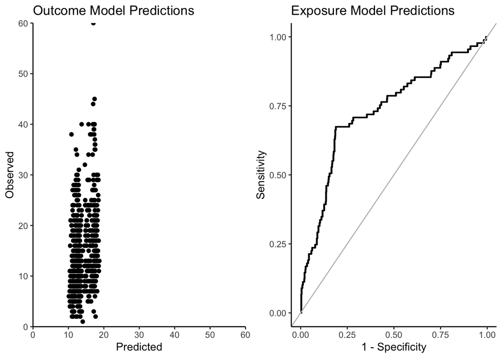

```r
plot_dat_mu <- tibble(Predicted = forest$Y.hat,
                   Observed = outcome)

rf_mu_fit_plot <- ggplot(plot_dat_mu) +
  geom_point(aes(x = Predicted,
                 y = Observed)) +
  scale_x_continuous(expand = c(0,0), limits = c(0,60)) +
  scale_y_continuous(expand = c(0,0), limits = c(0,60)) +
  ggtitle("Outcome Model Predictions")

a <- roc(factor(exposure), forest$W.hat, direction="auto")
plot_dat_pi <- data.frame(sens=a$sensitivities,spec=a$specificities)

rf_pi_fit_plot <- ggplot(plot_dat_pi) +
  geom_step(aes(1-spec,sens),linewidth=.75) +
  theme(panel.grid.major = element_blank(),
        panel.grid.minor = element_blank()) +
  labs(x = "1 - Specificity",y = "Sensitivity") +
  geom_abline(intercept=0,slope=1,col="gray")  +
  ggtitle("Exposure Model Predictions")

rf_diag_plot <- grid.arrange(rf_mu_fit_plot,
             rf_pi_fit_plot,
             ncol = 2)
```

This figure shows fairly poor performance of the random forest algorithms for both the outcome and propensity score models.

It’s also important to evaluate propensity score overlap:

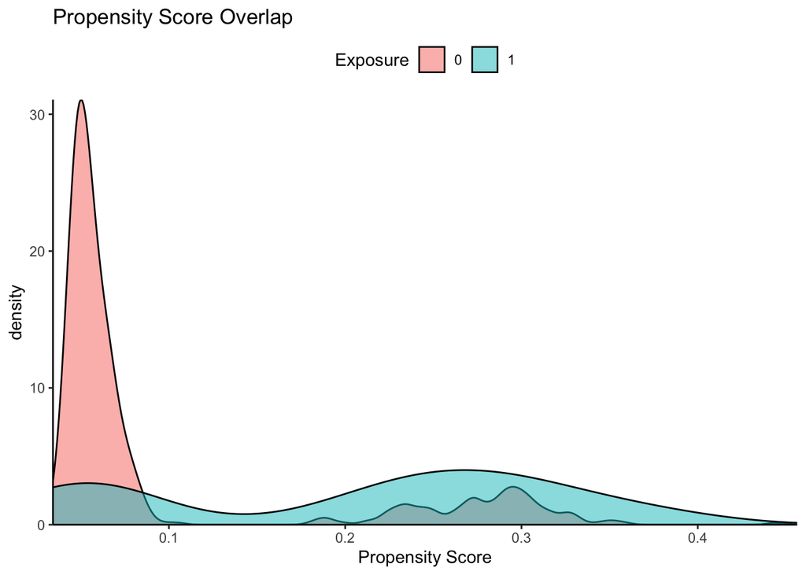

```r
plot_dat_ps <- tibble(`Propensity Score` = forest$W.hat,
                      Exposure = factor(exposure))

rf_ps_overlap_plot <- ggplot(plot_dat_ps) +
  geom_density(aes(x = `Propensity Score`,
                   group = Exposure,
                   fill = Exposure), alpha = .5) +
  scale_x_continuous(expand = c(0,0)) +
  scale_y_continuous(expand = c(0,0)) +
  ggtitle("Propensity Score Overlap")

rf_ps_overlap_plot
```

Once these diagnostics are complete, we can construct an estimate of the ATE using the predictions from the random forest fit in the causal forest algorithm.

```r
# we then use the `average_treatment_effect()` function to obtain an ATE estimate
cf_ate <- average_treatment_effect(forest) # this code shows that it's using AIPW or TMLE to get ATE.
# this treatment effect is obtained via random forests using singly robust estimator
cf_ate <- cbind(t(cf_ate),
      cf_ate[1] - 1.96*cf_ate[2],
      cf_ate[1] + 1.96*cf_ate[2])

colnames(cf_ate)[3:4] <- c("LCL", "UCL")

cf_ate
```

```
##           estimate   std.err       LCL       UCL
## estimate -7.286605 0.8741973 -9.000032 -5.573178
```

Next, we’ll construct an AIPW estimator for the ATE using stacking (SuperLearner) as the machine learning algorithm of interest. In this case, we’ll fit the super learner algorithm for the propensity score model and for the outcome model. We’ll also use the same folds as above for sample splitting:

```r
## test
##
#
# screen.glmnet <- function(Y, X, family, alpha = 1, minscreen = 2, nfolds = 10, nlambda = 100,  ...) {
#   .SL.require('glmnet')
#   if(!is.matrix(X)) {
#     X <- model.matrix(~ -1 + ., X)
#   }
#   fitCV <- glmnet::cv.glmnet(x = X, y = Y, lambda = NULL, type.measure = 'deviance', nfolds = nfolds, family = family$family, alpha = alpha, nlambda = nlambda)
#   whichVariable <- (as.numeric(coef(fitCV$glmnet.fit, s = fitCV$lambda.min))[-1] != 0)
#   # the [-1] removes the intercept
#   if (sum(whichVariable) < minscreen) {
#       warning("fewer than minscreen variables passed the glmnet screen, increased lambda to allow minscreen variables")
#       sumCoef <- apply(as.matrix(fitCV$glmnet.fit$beta), 2, function(x) sum((x != 0)))
#       newCut <- which.max(sumCoef >= minscreen)
#       whichVariable <- (as.matrix(fitCV$glmnet.fit$beta)[, newCut] != 0)
#   }
#   return(whichVariable)
# }
#
#
#
# fitCV <- glmnet::cv.glmnet(x = model.matrix(~ -1 + ., covariates_matrix_w_augment),
#                            y = outcome,
#                            lambda = NULL,
#                            type.measure = 'deviance',
#                            nfolds = 10,
#                            family = "gaussian",
#                            alpha = 1,
#                            nlambda = 100)
#
# coef(fitCV, s = fitCV$lambda.min)
#
#   whichVariable <- (as.numeric(coef(fitCV$glmnet.fit, s = fitCV$lambda.min))[-1] != 0)
#
#   if (sum(whichVariable) < minscreen) {
#       warning("fewer than minscreen variables passed the glmnet screen, increased lambda to allow minscreen variables")
#       sumCoef <- apply(as.matrix(fitCV$glmnet.fit$beta), 2, function(x) sum((x != 0)))
#       newCut <- which.max(sumCoef >= minscreen)
#       whichVariable <- (as.matrix(fitCV$glmnet.fit$beta)[, newCut] != 0)
#   }
#
#   names(covariates_matrix_w_augment)[whichVariable]
#
##
## end test


mean_learner <- "SL.mean"
glm_learner <- "SL.glm"

# ranger learner
ranger_learner <- create.Learner("SL.ranger",
                                 params = list(num.trees = 500,
                                               min.node.size = 50),
                                 tune = list(mtry = c(3,4,5)))

# glmnet learner
glmnet_learner <- create.Learner("SL.glmnet",
                                 tune = list(alpha = seq(0,1,.25)))

# xgboost learner
xgboost_learner <- create.Learner("SL.xgboost",
                                 params = list(nrounds = 500),
                                 tune = list(max_depth = c(4,6),
                                             eta = c(.1,.2)))

# earth learner
earth_learner <- create.Learner("SL.earth",
                                tune = list(degree = c(3,4,5)))

.SL.require <- function(package, message = paste('loading required package (', package, ') failed', sep = '')) {
  if(!requireNamespace(package, quietly = FALSE)) {
    stop(message, call. = FALSE)
  }
  invisible(TRUE)
}
screen.glmnet1 <- function (Y, X, family, alpha = 1, minscreen = 20, nfolds = 10,
    nlambda = 100, ...)
{
    .SL.require("glmnet")
    if (!is.matrix(X)) {
        X <- model.matrix(~-1 + ., X)
    }
    fitCV <- glmnet::cv.glmnet(x = X, y = Y, lambda = NULL, type.measure = "deviance",
        nfolds = nfolds, family = family$family, alpha = alpha,
        nlambda = nlambda)
    whichVariable <- (as.numeric(coef(fitCV$glmnet.fit, s = fitCV$lambda.min))[-1] !=
        0)
    if (sum(whichVariable) < minscreen) {
        warning("fewer than minscreen variables passed the glmnet screen, increased lambda to allow minscreen variables")
        sumCoef <- apply(as.matrix(fitCV$glmnet.fit$beta), 2,
            function(x) sum((x != 0)))
        newCut <- which.max(sumCoef >= minscreen)
        whichVariable <- (as.matrix(fitCV$glmnet.fit$beta)[,
            newCut] != 0)
    }
    return(whichVariable)
}

sl_lib <- c(ranger_learner$names,
            glmnet_learner$names,
            xgboost_learner$names,
            earth_learner$names,
            list(mean_learner,
                 glm_learner,
                 # c(ranger_learner$names[1], "screen.glmnet1"),
                 # c(ranger_learner$names[2], "screen.glmnet1"),
                 # c(ranger_learner$names[3], "screen.glmnet1"),
                 c(glmnet_learner$names[1], "screen.glmnet1"),
                 c(glmnet_learner$names[2], "screen.glmnet1"),
                 c(glmnet_learner$names[3], "screen.glmnet1"),
                 c(glmnet_learner$names[4], "screen.glmnet1"),
                 c(glmnet_learner$names[5], "screen.glmnet1"),
                 c(xgboost_learner$names[1], "screen.glmnet1"),
                 c(xgboost_learner$names[2], "screen.glmnet1"),
                 c(xgboost_learner$names[3], "screen.glmnet1"),
                 c(xgboost_learner$names[4], "screen.glmnet1"),
                 c(earth_learner$names[1], "screen.glmnet1"),
                 c(earth_learner$names[2], "screen.glmnet1"),
                 c(earth_learner$names[3], "screen.glmnet1")))

# Specify the number of folds for V-fold cross-validation
# Use same folds as used for causal_forest function
# Doing cross-validation this way automatically deploys cross-fitting
fold_dat <- tibble(id = 1:n,folds)
fold_index <- split(fold_dat$id,fold_dat$folds)

# we'll use parallel processing to speed things up
options(mc.cores = detectCores() - 2)

getOption("mc.cores")
```

```
## [1] 10
```

```r
augment_data <- covariates_matrix_w[,env_vars]*covariates_matrix_w$DOR
names(augment_data) <- paste0(names(augment_data),"_DOR")

covariates_matrix_w_augment <- cbind(covariates_matrix_w, augment_data)

fit_mu <- CV.SuperLearner(Y = outcome,
                          X = covariates_matrix_w_augment,
                          method = "method.NNLS",
                          family = gaussian,
                          SL.library = sl_lib,
                          cvControl = list(V = num.folds, validRows = fold_index),
                          control = list(saveCVFitLibrary = T),
                          parallel = "multicore",
                          verbose = T)

fit_pi <- CV.SuperLearner(Y = exposure,
                          X = covariates_matrix,
                          method = "method.NNLS",
                          family = binomial,
                          SL.library = sl_lib,
                          cvControl = list(V = num.folds, validRows = fold_index),
                          control = list(saveCVFitLibrary = T),
                          parallel = "multicore",
                          verbose = T)
```

Let’s explore the fit for each of these stacked algorithms. First, we’ll examine the stacking results for the model fits:

```r
summary(fit_mu)
```

```
##
## Call:
## CV.SuperLearner(Y = outcome, X = covariates_matrix_w_augment, family = gaussian,
##     SL.library = sl_lib, method = "method.NNLS", verbose = T, control = list(saveCVFitLibrary = T),
##     cvControl = list(V = num.folds, validRows = fold_index), parallel = "multicore")
##
##
## Risk is based on: Mean Squared Error
##
## All risk estimates are based on V =  10
##
##                    Algorithm     Ave      se    Min     Max
##                Super Learner  49.628  4.0592 33.280  69.285
##                  Discrete SL  49.198  4.0162 34.470  69.976
##              SL.ranger_1_All  51.594  4.2794 32.504  72.921
##              SL.ranger_2_All  51.302  4.2185 32.454  71.822
##              SL.ranger_3_All  50.815  4.1386 32.584  70.720
##              SL.glmnet_1_All  50.673  4.1344 34.433  70.243
##              SL.glmnet_2_All  49.432  4.0734 34.349  70.855
##              SL.glmnet_3_All  49.461  4.0452 34.660  70.604
##              SL.glmnet_4_All  49.280  4.0257 34.557  69.976
##              SL.glmnet_5_All  49.524  4.0698 34.470  70.792
##             SL.xgboost_1_All  65.409  4.4799 46.572  83.879
##             SL.xgboost_2_All  62.434  4.3593 42.489  85.260
##             SL.xgboost_3_All  65.409  4.4799 46.572  83.879
##             SL.xgboost_4_All  62.434  4.3593 42.489  85.260
##               SL.earth_1_All 131.109 71.0477 37.661 750.794
##               SL.earth_2_All  73.167 13.2048 38.060 179.196
##               SL.earth_3_All  72.224 12.3534 38.281 170.546
##                  SL.mean_All  61.478  4.8268 40.289  89.487
##                   SL.glm_All  52.194  4.0815 35.228  73.405
##   SL.glmnet_1_screen.glmnet1  49.546  4.0352 35.137  68.207
##   SL.glmnet_2_screen.glmnet1  49.551  4.0470 34.781  70.888
##   SL.glmnet_3_screen.glmnet1  49.874  4.0168 35.130  70.214
##   SL.glmnet_4_screen.glmnet1  49.306  3.9833 34.654  68.326
##   SL.glmnet_5_screen.glmnet1  49.409  3.9777 34.715  67.361
##  SL.xgboost_1_screen.glmnet1  66.347  4.7336 47.943  80.561
##  SL.xgboost_2_screen.glmnet1  64.988  4.7546 47.077  87.615
##  SL.xgboost_3_screen.glmnet1  66.347  4.7336 47.943  80.561
##  SL.xgboost_4_screen.glmnet1  64.988  4.7546 47.077  87.615
##    SL.earth_1_screen.glmnet1  52.945  4.1033 36.096  69.571
##    SL.earth_2_screen.glmnet1  53.690  4.1649 37.779  73.507
##    SL.earth_3_screen.glmnet1  54.103  4.1744 36.584  73.507
```

```r
summary(fit_pi)
```

```
##
## Call:
## CV.SuperLearner(Y = exposure, X = covariates_matrix, family = binomial, SL.library = sl_lib,
##     method = "method.NNLS", verbose = T, control = list(saveCVFitLibrary = T),
##     cvControl = list(V = num.folds, validRows = fold_index), parallel = "multicore")
##
##
## Risk is based on: Mean Squared Error
##
## All risk estimates are based on V =  10
##
##                    Algorithm      Ave        se      Min     Max
##                Super Learner 0.089801 0.0075646 0.036026 0.14478
##                  Discrete SL 0.089614 0.0075486 0.035556 0.14419
##              SL.ranger_1_All 0.095050 0.0079798 0.037248 0.15301
##              SL.ranger_2_All 0.094368 0.0078462 0.038533 0.15029
##              SL.ranger_3_All 0.093954 0.0077730 0.040060 0.14862
##              SL.glmnet_1_All 0.093911 0.0079569 0.035081 0.15878
##              SL.glmnet_2_All 0.091661 0.0077632 0.035050 0.15169
##              SL.glmnet_3_All 0.090471 0.0076487 0.034929 0.14817
##              SL.glmnet_4_All 0.089825 0.0075784 0.035114 0.14517
##              SL.glmnet_5_All 0.089724 0.0075561 0.035556 0.14495
##             SL.xgboost_1_All 0.113176 0.0094805 0.052079 0.18735
##             SL.xgboost_2_All 0.112407 0.0094796 0.049145 0.18728
##             SL.xgboost_3_All 0.113176 0.0094805 0.052079 0.18735
##             SL.xgboost_4_All 0.112407 0.0094796 0.049145 0.18728
##               SL.earth_1_All 0.116834 0.0098882 0.067438 0.15860
##               SL.earth_2_All 0.126196 0.0103571 0.057858 0.19350
##               SL.earth_3_All 0.125557 0.0103763 0.057858 0.19350
##                  SL.mean_All 0.102173 0.0088617 0.034820 0.16474
##                   SL.glm_All 0.096186 0.0080553 0.036415 0.16695
##   SL.glmnet_1_screen.glmnet1 0.093780 0.0079569 0.034966 0.15948
##   SL.glmnet_2_screen.glmnet1 0.092044 0.0078051 0.035721 0.15339
##   SL.glmnet_3_screen.glmnet1 0.090645 0.0076653 0.035538 0.14941
##   SL.glmnet_4_screen.glmnet1 0.090026 0.0075975 0.035231 0.14517
##   SL.glmnet_5_screen.glmnet1 0.089605 0.0075517 0.035335 0.14419
##  SL.xgboost_1_screen.glmnet1 0.112204 0.0094838 0.052956 0.18255
##  SL.xgboost_2_screen.glmnet1 0.111525 0.0094815 0.052704 0.18429
##  SL.xgboost_3_screen.glmnet1 0.112204 0.0094838 0.052956 0.18255
##  SL.xgboost_4_screen.glmnet1 0.111525 0.0094815 0.052704 0.18429
##    SL.earth_1_screen.glmnet1 0.110783 0.0094388 0.066313 0.18815
##    SL.earth_2_screen.glmnet1 0.119916 0.0099337 0.058369 0.19424
##    SL.earth_3_screen.glmnet1 0.118620 0.0099086 0.058369 0.19424
```

We can also construct permutation based variable importance measures for the outcome model with superlearner using the `vip` package:

```r
fit_mu_2 <- mcSuperLearner(Y = outcome,
                           X = covariates_matrix_w_augment,
                           method = "method.NNLS",
                           family = gaussian,
                           SL.library = sl_lib,
                           cvControl = list(V = num.folds, validRows = fold_index),
                           control = list(saveCVFitLibrary = T),
                           verbose = T)
```

```
## Non-Negative least squares convergence: TRUE
```

```
## Non-Negative least squares convergence: TRUE
```

```r
pred_wrapper <- function(sl, newdata) {
  predict(sl, newdata, onlySL=T)$pred
}

VarImpSL <- vi_permute(object = fit_mu_2,
                 method = "permute",
                 feature_names = names(covariates_matrix),
                 train = covariates_matrix_w_augment,
                 target = outcome,
                 metric = "RMSE",
                 type = "difference",
                 nsim = 5,
                 pred_wrapper = pred_wrapper)

names(VarImpSL) <- c("Variable", "Importance", "SD")

VarImpSL <- VarImpSL[,c("Variable","Importance")]
```

Let’s compare the variable importance measures from each approach:

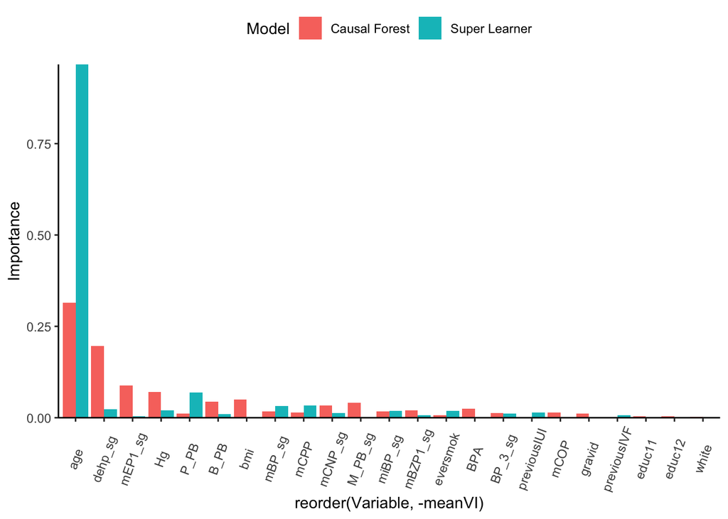

```r
VarImpSL$Model <- "Super Learner"
VarImpRf$Model <- "Causal Forest"

VarImp <- rbind(VarImpRf, VarImpSL)

mean_for_rank <- VarImp %>%
  group_by(Variable) %>%
  summarize(meanVI = mean(Importance))

VarImp <- left_join(VarImp, mean_for_rank, by = "Variable")
var_names <- unique(VarImp[order(-VarImp$meanVI),]$Variable)
var_names <- var_names[env_vars][1:5] # to save for later...

ggplot(VarImp) +
  geom_bar(aes(x = reorder(Variable, -meanVI),
               y = Importance,
               fill = Model),
           position="dodge",
           stat="identity") +
  theme(axis.text.x = element_text(angle = 70,
                                   vjust = 0.5,
                                   hjust=.5)) +
  scale_y_continuous(expand = c(0,0))
```

```r
## create separate variable list for cf versus drl

var_names_rf <- unique(VarImpRf[order(-VarImpRf$Importance),]$Variable)
var_names_rf <- var_names_rf[var_names_rf %in% env_vars][1:14] # to save for later...

var_names_sl <- unique(VarImpSL[order(-VarImpSL$Importance),]$Variable)
var_names_sl <- var_names_sl[var_names_sl %in% env_vars][1:14] # to save for later...
```

We’ll also construct the same diagnostics for the super learner models.

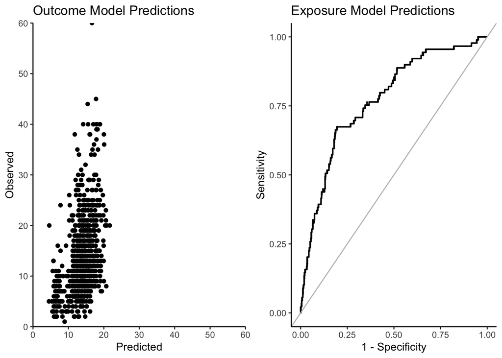

```r
plot_dat_mu <- tibble(Predicted = fit_mu$SL.predict,
                      Observed = outcome)

sl_mu_fit_plot <- ggplot(plot_dat_mu) +
  geom_point(aes(x = Predicted,
                 y = Observed)) +
  scale_x_continuous(expand = c(0,0), limits = c(0,60)) +
  scale_y_continuous(expand = c(0,0), limits = c(0,60)) +
  ggtitle("Outcome Model Predictions")

a <- roc(factor(exposure), fit_pi$SL.predict, direction="auto")
plot_dat_pi <- data.frame(sens=a$sensitivities,spec=a$specificities)

sl_pi_fit_plot <- ggplot(plot_dat_pi) +
  geom_step(aes(1-spec,sens),linewidth=.75) +
  theme(panel.grid.major = element_blank(),
        panel.grid.minor = element_blank()) +
  labs(x = "1 - Specificity",y = "Sensitivity") +
  geom_abline(intercept=0,slope=1,col="gray")  +
  ggtitle("Exposure Model Predictions")

sl_diag_plot <- grid.arrange(sl_mu_fit_plot,
             sl_pi_fit_plot,
             ncol = 2)
```

Here is the propensity score overlap plot for the super learner model as well:

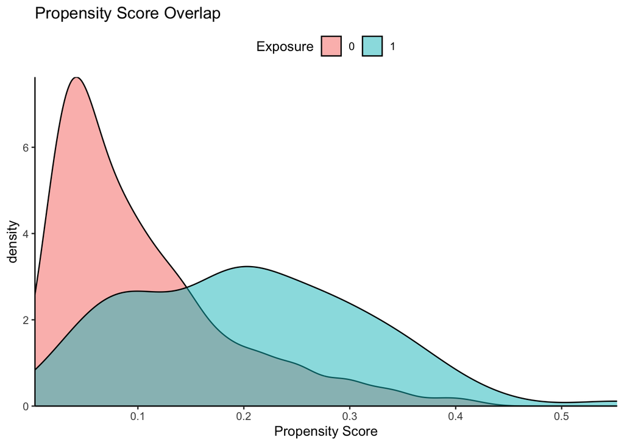

```r
plot_dat_ps <- tibble(`Propensity Score` = fit_pi$SL.predict,
                      Exposure = factor(exposure))

sl_ps_overlap_plot <- ggplot(plot_dat_ps) +
  geom_density(aes(x = `Propensity Score`,
                   group = Exposure,
                   fill = Exposure), alpha = .5) +
  scale_x_continuous(expand = c(0,0)) +
  scale_y_continuous(expand = c(0,0)) +
  ggtitle("Propensity Score Overlap")

sl_ps_overlap_plot
```

Again, with these diagnostics complete, we can construct and ATE estimate using the double robust AIPW estimator, with the exposure and outcome models obtained via stacking:

```r
## cross-fit predictions

pscore <- as.matrix(fit_pi$SL.predict)

mu_hat <- as.matrix(fit_mu$SL.predict)

mu_hat1 <- NULL
for(i in 1:num.folds){
mu_hat1 <- rbind(mu_hat1,
                 predict(fit_mu$AllSL[[i]],
                   newdata = base::transform(
                     covariates_matrix_w_augment[fold_index[[i]],], DOR = 1),
                           onlySL=T)$pred)
}
mu_hat0 <- NULL
for(i in 1:num.folds){
mu_hat0 <- rbind(mu_hat0,
                 predict(fit_mu$AllSL[[i]],
                   newdata = base::transform(
                     covariates_matrix_w_augment[fold_index[[i]],], DOR = 0),
                           onlySL=T)$pred)
}

## aipw
aipw_func <- function(exposure, outcome, pscore, mu_hat, mu_hat0, mu_hat1){
  aipw_score <- ((2*exposure - 1)*(outcome - mu_hat))/((2*exposure - 1)*pscore + (1 - exposure)) + (mu_hat1 - mu_hat0)
  return(aipw_score)
}

aipw_score <- aipw_func(exposure,
                        outcome,
                        pscore,
                        mu_hat,
                        mu_hat0,
                        mu_hat1)
colnames(aipw_score) <- NULL

aipw_psi <- mean(aipw_score)

aipw_se <- sd(aipw_score)/sqrt(n)

aipw_ate <- c(aipw_psi, aipw_se)

aipw_ate <- cbind(t(aipw_ate),
      aipw_ate[1] - 1.96*aipw_ate[2],
      aipw_ate[1] + 1.96*aipw_ate[2])

colnames(aipw_ate) <- c("estimate", "std.err", "LCL", "UCL")

covariates_matrix$aipw_score <- aipw_score
covariates_matrix$forest_score <- get_scores(forest)
```

Our first set of results are basically estimates of the average treatment effect using singly robust causal forests, and double robust AIPW. Both approaches deployed a form of cross-fitting, so that the same observations were not used to fit the models and then construct the estimates.

The overall ATE results are as follows:

```r
res_ate <-  rbind(cf_ate,
                  aipw_ate)

row.names(res_ate) <- c("Causal Forest", "AIPW with Stacking")

res_ate
```

```
##                     estimate   std.err       LCL       UCL
## Causal Forest      -7.286605 0.8741973 -9.000032 -5.573178
## AIPW with Stacking -5.931082 0.9955818 -7.882422 -3.979741
```

## Conditional Average Treatment Effects

```r
tau.hat = predict(forest)$predictions

# Compare regions with high and low estimated CATEs
high_effect = tau.hat > median (tau.hat)
ate.high = average_treatment_effect(forest, subset = high_effect)
ate.low = average_treatment_effect(forest, subset = !high_effect)
ate.high
```

```
##   estimate    std.err
## -5.9284114  0.8292117
```

```r
ate.low
```

```
##  estimate   std.err
## -8.641298  1.393178
```

```r
# Run best linear predictor analysis
test_calibration(forest)
```

```
##
## Best linear fit using forest predictions (on held-out data)
## as well as the mean forest prediction as regressors, along
## with one-sided heteroskedasticity-robust (HC3) SEs:
##
##                                Estimate Std. Error t value  Pr(>t)
## mean.forest.prediction          1.06472    0.12072  8.8199 < 2e-16 ***
## differential.forest.prediction  1.27257    0.65877  1.9317 0.02688 *
## ---
## Signif. codes:  0 '***' 0.001 '**' 0.01 '*' 0.05 '.' 0.1 ' ' 1
```

If `mean.forest.prediction` = 1, then the average prediction produced by the forest is correct. Meanwhile, if `differential.forest.prediction` = 1, then the forest predictions adequately capture the underlying heterogeneity.

The slope `differential.forest.prediction` is a measure of how the CATE predictions covary with true CATE. Therefore, the p-value on the estimate of coefficient also acts as an omnibus test for the presence of heterogeneity. If the coefficient is significantly greater than zero, then we can reject the null of no heterogeneity. However, coefficients smaller than 0 are not meaningful and should not be interpreted.

```r
best_linear_projection(forest, covariates_matrix[,c(var_names_rf)])
```

```
##
## Best linear projection of the conditional average treatment effect.
## Confidence intervals are cluster- and heteroskedasticity-robust (HC3):
##
##             Estimate Std. Error t value  Pr(>|t|)
## (Intercept)  -7.9808     1.9134 -4.1710 3.382e-05 ***
## dehp_sg      14.6363    21.7554  0.6728   0.50130
## mEP1_sg       1.9160     8.2677  0.2317   0.81680
## Hg           -3.5698    12.7977 -0.2789   0.78037
## B_PB          6.0887     8.3235  0.7315   0.46469
## M_PB_sg      -5.2246     9.0866 -0.5750   0.56548
## mCNP_sg      12.6603     6.0971  2.0764   0.03819 *
## BPA           3.4958     8.8134  0.3967   0.69174
## mBZP1_sg      2.8615     4.5927  0.6231   0.53343
## miBP_sg       1.7426     9.9078  0.1759   0.86043
## mBP_sg        9.3575     5.4924  1.7037   0.08884 .
## mCOP         -9.4069    13.3481 -0.7047   0.48119
## mCPP         -6.7968    13.7107 -0.4957   0.62023
## BP_3_sg      -7.7847    10.6384 -0.7318   0.46454
## P_PB         10.5212     2.5827  4.0737 5.113e-05 ***
## ---
## Signif. codes:  0 '***' 0.001 '**' 0.01 '*' 0.05 '.' 0.1 ' ' 1
```

Let’s look at a similar best linear projection with the DR learner approach

```r
score_dat <- data.frame(aipw_score, covariates_matrix[,c(var_names_sl)])
score_fit <- lm(aipw_score ~ ., data = score_dat)
coeftest(score_fit, vcov = vcovHC(score_fit, type = "HC3"))
```

```
##
## t test of coefficients:
##
##               Estimate Std. Error t value  Pr(>|t|)
## (Intercept)  -5.853255   1.625544 -3.6008 0.0003379 ***
## P_PB         10.394248   6.377034  1.6300 0.1035264
## mCPP         -0.089696  22.855552 -0.0039 0.9968698
## mBP_sg       11.751613   7.413018  1.5853 0.1133217
## dehp_sg      16.035120  11.265097  1.4234 0.1550208
## Hg          -17.430867  19.190739 -0.9083 0.3640099
## miBP_sg       5.943093  15.220935  0.3905 0.6963094
## mCNP_sg      11.403242   5.716999  1.9946 0.0464411 *
## BP_3_sg       0.923876   8.751563  0.1056 0.9159538
## B_PB         10.329686   8.190553  1.2612 0.2076343
## mBZP1_sg      6.416331   5.790583  1.1081 0.2681852
## mEP1_sg       4.302040   7.732045  0.5564 0.5781074
## BPA           7.161367   8.274379  0.8655 0.3870447
## M_PB_sg      -4.489887  34.944707 -0.1285 0.8977988
## mCOP        -16.040249  16.515517 -0.9712 0.3317462
## ---
## Signif. codes:  0 '***' 0.001 '**' 0.01 '*' 0.05 '.' 0.1 ' ' 1
```

```r
ss10 <- smooth.spline(covariates_matrix$P_PB,
                      covariates_matrix$aipw_score,
                      df = 3,
                      cv = F
                      )
ss11 <- smooth.spline(covariates_matrix$P_PB,
                      covariates_matrix$forest_score,
                      df = 3,
                      cv = F
                      )

row1 <- data.frame(
  PB = as.matrix(ss10$x),
  CATE = as.matrix(ss10$y),
  Method = as.matrix(rep("DR Learner", length(ss10$x)))
  )
row2 <- data.frame(
  PB = as.matrix(ss10$x),
  CATE = as.matrix(ss11$y),
  Method = as.matrix(rep("Causal Forest", length(ss10$x)))
  )

plot_dat <- rbind(
  rbind(row1,row2)
  )

plot_dat$PB <- plot_dat$PB*(max(afc_clean$P_PB) - min(afc_clean$P_PB)) + min(afc_clean$P_PB)

head(plot_dat)
```

```
##          PB      CATE     Method
## 1 0.0700000 -6.854809 DR Learner
## 2 0.1414214 -6.853963 DR Learner
## 3 0.2000000 -6.853269 DR Learner
## 4 0.3000000 -6.852084 DR Learner
## 5 0.4000000 -6.850899 DR Learner
## 6 0.5000000 -6.849714 DR Learner
```

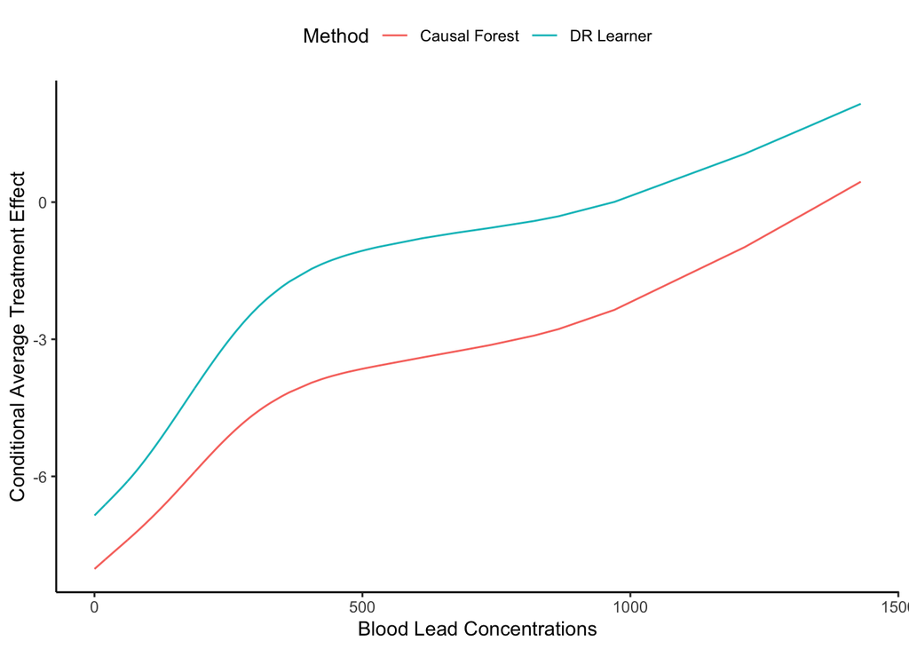

```r
ggplot(plot_dat) +
  geom_line(aes(y = CATE,
                x = PB,
                group = Method,
                color = Method)) +
  xlab("Blood Lead Concentrations") +
  ylab("Conditional Average Treatment Effect")
```

```r
ss10 <- smooth.spline(covariates_matrix$mCNP_sg,
                      covariates_matrix$aipw_score,
                      df = 3,
                      cv = F
                      )
ss11 <- smooth.spline(covariates_matrix$mCNP_sg,
                      covariates_matrix$forest_score,
                      df = 3,
                      cv = F
                      )

row1 <- data.frame(
  mCNP = as.matrix(ss10$x),
  CATE = as.matrix(ss10$y),
  Method = as.matrix(rep("DR Learner", length(ss10$x)))
  )
row2 <- data.frame(
  mCNP = as.matrix(ss10$x),
  CATE = as.matrix(ss11$y),
  Method = as.matrix(rep("Causal Forest", length(ss10$x)))
  )

plot_dat <- rbind(
  rbind(row1,row2)
  )

plot_dat$mCNP <- plot_dat$mCNP*(max(afc_clean$mCNP_sg) - min(afc_clean$mCNP_sg)) + min(afc_clean$mCNP_sg)

head(plot_dat)
```

```
##        mCNP      CATE     Method
## 1 0.1909091 -6.131967 DR Learner
## 2 0.3500000 -6.130001 DR Learner
## 3 0.4000000 -6.129383 DR Learner
## 4 0.4200000 -6.129135 DR Learner
## 5 0.4242641 -6.129083 DR Learner
## 6 0.4500000 -6.128764 DR Learner
```

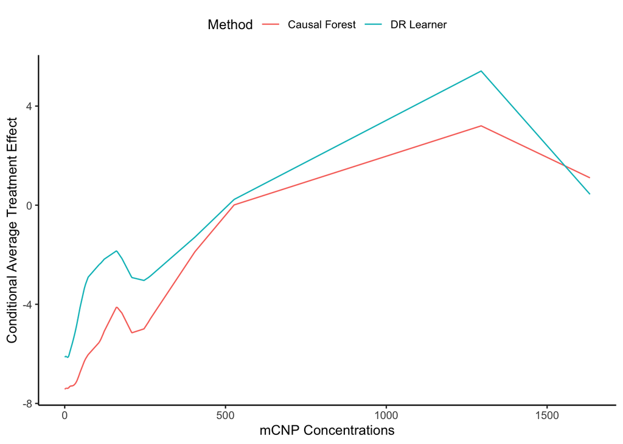

```r
ggplot(plot_dat) +
  geom_line(aes(y = CATE,
                x = mCNP,
                group = Method,
                color = Method)) +
  xlab("mCNP Concentrations") +
  ylab("Conditional Average Treatment Effect")
```

```r
ss10 <- smooth.spline(covariates_matrix$Hg,
                      covariates_matrix$aipw_score,
                      df = 3,
                      cv = F
                      )
ss11 <- smooth.spline(covariates_matrix$Hg,
                      covariates_matrix$forest_score,
                      df = 3,
                      cv = F
                      )

row1 <- data.frame(
  Hg = as.matrix(ss10$x),
  CATE = as.matrix(ss10$y),
  Method = as.matrix(rep("DR Learner", length(ss10$x)))
  )
row2 <- data.frame(
  Hg = as.matrix(ss10$x),
  CATE = as.matrix(ss11$y),
  Method = as.matrix(rep("Causal Forest", length(ss10$x)))
  )

plot_dat <- rbind(
  rbind(row1,row2)
  )

plot_dat$Hg <- plot_dat$Hg*(max(afc_clean$Hg) - min(afc_clean$Hg)) + min(afc_clean$Hg)

head(plot_dat)
```

```
##          Hg      CATE     Method
## 1  2.744300 -5.129421 DR Learner
## 2  8.591083 -5.130558 DR Learner
## 3 11.734900 -5.131169 DR Learner
## 4 13.057480 -5.131427 DR Learner
## 5 17.560100 -5.132302 DR Learner
## 6 18.640000 -5.132512 DR Learner
```

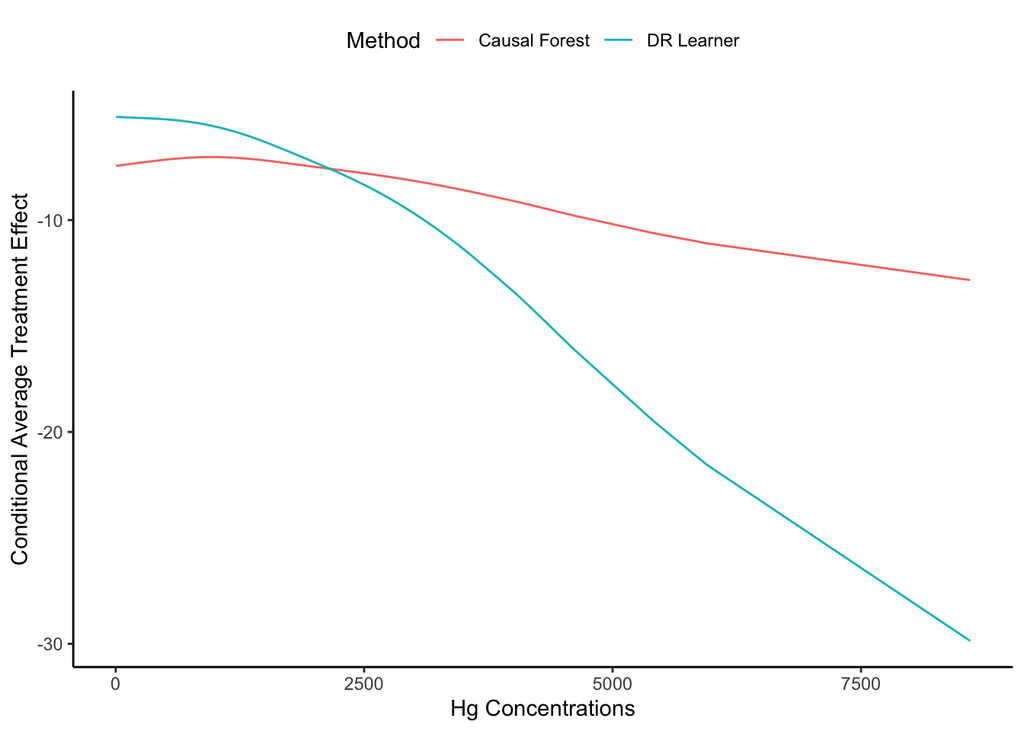

```r
ggplot(plot_dat) +
  geom_line(aes(y = CATE,
                x = Hg,
                group = Method,
                color = Method)) +
  xlab("Hg Concentrations") +
  ylab("Conditional Average Treatment Effect")
```